# Risk Factor Analysis

## Outcome Variable

**Outcome Variable:** wast_rec90d

## Predictor Variables

**Intervention Variable:** month

**Adjustment Set:**

unadjusted

## Stratifying Variables

The analysis was stratified on these variable(s):

- agecat
- studyid
- country

## Data Summary

| agecat | studyid | country | month | wast_rec90d | n_cell | n |
| --- | --- | --- | --- | --- | --- | --- |
| 0-24 months | ki0047075b-MAL-ED | BANGLADESH | 1 | 0 | 1 | 124 |
| 0-24 months | ki0047075b-MAL-ED | BANGLADESH | 1 | 1 | 4 | 124 |
| 0-24 months | ki0047075b-MAL-ED | BANGLADESH | 2 | 0 | 7 | 124 |
| 0-24 months | ki0047075b-MAL-ED | BANGLADESH | 2 | 1 | 10 | 124 |
| 0-24 months | ki0047075b-MAL-ED | BANGLADESH | 3 | 0 | 8 | 124 |
| 0-24 months | ki0047075b-MAL-ED | BANGLADESH | 3 | 1 | 15 | 124 |
| 0-24 months | ki0047075b-MAL-ED | BANGLADESH | 4 | 0 | 4 | 124 |
| 0-24 months | ki0047075b-MAL-ED | BANGLADESH | 4 | 1 | 5 | 124 |
| 0-24 months | ki0047075b-MAL-ED | BANGLADESH | 5 | 0 | 6 | 124 |
| 0-24 months | ki0047075b-MAL-ED | BANGLADESH | 5 | 1 | 6 | 124 |
| 0-24 months | ki0047075b-MAL-ED | BANGLADESH | 6 | 0 | 1 | 124 |
| 0-24 months | ki0047075b-MAL-ED | BANGLADESH | 6 | 1 | 1 | 124 |
| 0-24 months | ki0047075b-MAL-ED | BANGLADESH | 7 | 0 | 4 | 124 |
| 0-24 months | ki0047075b-MAL-ED | BANGLADESH | 7 | 1 | 9 | 124 |
| 0-24 months | ki0047075b-MAL-ED | BANGLADESH | 8 | 0 | 1 | 124 |
| 0-24 months | ki0047075b-MAL-ED | BANGLADESH | 8 | 1 | 3 | 124 |
| 0-24 months | ki0047075b-MAL-ED | BANGLADESH | 9 | 0 | 5 | 124 |
| 0-24 months | ki0047075b-MAL-ED | BANGLADESH | 9 | 1 | 16 | 124 |
| 0-24 months | ki0047075b-MAL-ED | BANGLADESH | 10 | 0 | 3 | 124 |
| 0-24 months | ki0047075b-MAL-ED | BANGLADESH | 10 | 1 | 3 | 124 |
| 0-24 months | ki0047075b-MAL-ED | BANGLADESH | 11 | 0 | 2 | 124 |
| 0-24 months | ki0047075b-MAL-ED | BANGLADESH | 11 | 1 | 2 | 124 |
| 0-24 months | ki0047075b-MAL-ED | BANGLADESH | 12 | 0 | 3 | 124 |
| 0-24 months | ki0047075b-MAL-ED | BANGLADESH | 12 | 1 | 5 | 124 |
| 0-24 months | ki0047075b-MAL-ED | BRAZIL | 1 | 0 | 0 | 23 |
| 0-24 months | ki0047075b-MAL-ED | BRAZIL | 1 | 1 | 2 | 23 |
| 0-24 months | ki0047075b-MAL-ED | BRAZIL | 2 | 0 | 1 | 23 |
| 0-24 months | ki0047075b-MAL-ED | BRAZIL | 2 | 1 | 2 | 23 |
| 0-24 months | ki0047075b-MAL-ED | BRAZIL | 3 | 0 | 1 | 23 |
| 0-24 months | ki0047075b-MAL-ED | BRAZIL | 3 | 1 | 0 | 23 |

[output cut: 1962 more lines]

The following strata were considered:

- agecat: 0-24 months, studyid: ki0047075b-MAL-ED, country: BANGLADESH
- agecat: 0-24 months, studyid: ki0047075b-MAL-ED, country: BRAZIL
- agecat: 0-24 months, studyid: ki0047075b-MAL-ED, country: INDIA
- agecat: 0-24 months, studyid: ki0047075b-MAL-ED, country: NEPAL
- agecat: 0-24 months, studyid: ki0047075b-MAL-ED, country: PERU
- agecat: 0-24 months, studyid: ki0047075b-MAL-ED, country: SOUTH AFRICA
- agecat: 0-24 months, studyid: ki0047075b-MAL-ED, country: TANZANIA, UNITED REPUBLIC OF
- agecat: 0-24 months, studyid: ki1000108-CMC-V-BCS-2002, country: INDIA
- agecat: 0-24 months, studyid: ki1000108-IRC, country: INDIA
- agecat: 0-24 months, studyid: ki1000109-EE, country: PAKISTAN
- agecat: 0-24 months, studyid: ki1000109-ResPak, country: PAKISTAN
- agecat: 0-24 months, studyid: ki1000304b-SAS-CompFeed, country: INDIA
- agecat: 0-24 months, studyid: ki1000304b-SAS-FoodSuppl, country: INDIA
- agecat: 0-24 months, studyid: ki1017093-NIH-Birth, country: BANGLADESH
- agecat: 0-24 months, studyid: ki1066203-TanzaniaChild2, country: TANZANIA, UNITED REPUBLIC OF
- agecat: 0-24 months, studyid: ki1112895-Guatemala BSC, country: GUATEMALA
- agecat: 0-24 months, studyid: ki1112895-iLiNS-Zinc, country: BURKINA FASO
- agecat: 0-24 months, studyid: ki1113344-GMS-Nepal, country: NEPAL
- agecat: 0-24 months, studyid: ki1114097-CMIN, country: BANGLADESH
- agecat: 0-24 months, studyid: ki1114097-CMIN, country: BRAZIL
- agecat: 0-24 months, studyid: ki1114097-CMIN, country: GUINEA-BISSAU
- agecat: 0-24 months, studyid: ki1114097-CMIN, country: PERU
- agecat: 0-24 months, studyid: ki1114097-CONTENT, country: PERU
- agecat: 0-24 months, studyid: ki1119695-PROBIT, country: BELARUS
- agecat: 0-24 months, studyid: ki1126311-ZVITAMBO, country: ZIMBABWE
- agecat: 0-24 months, studyid: ki1148112-LCNI-5, country: MALAWI
- agecat: 0-24 months, studyid: kiGH5241-JiVitA-3, country: BANGLADESH
- agecat: 0-24 months, studyid: kiGH5241-JiVitA-4, country: BANGLADESH
- agecat: 0-6 months, studyid: ki0047075b-MAL-ED, country: BANGLADESH
- agecat: 0-6 months, studyid: ki0047075b-MAL-ED, country: BRAZIL
- agecat: 0-6 months, studyid: ki0047075b-MAL-ED, country: INDIA
- agecat: 0-6 months, studyid: ki0047075b-MAL-ED, country: NEPAL
- agecat: 0-6 months, studyid: ki0047075b-MAL-ED, country: PERU
- agecat: 0-6 months, studyid: ki0047075b-MAL-ED, country: SOUTH AFRICA
- agecat: 0-6 months, studyid: ki0047075b-MAL-ED, country: TANZANIA, UNITED REPUBLIC OF
- agecat: 0-6 months, studyid: ki1000108-CMC-V-BCS-2002, country: INDIA
- agecat: 0-6 months, studyid: ki1000108-IRC, country: INDIA
- agecat: 0-6 months, studyid: ki1000109-EE, country: PAKISTAN
- agecat: 0-6 months, studyid: ki1000109-ResPak, country: PAKISTAN
- agecat: 0-6 months, studyid: ki1000304b-SAS-CompFeed, country: INDIA
- agecat: 0-6 months, studyid: ki1000304b-SAS-FoodSuppl, country: INDIA
- agecat: 0-6 months, studyid: ki1017093-NIH-Birth, country: BANGLADESH
- agecat: 0-6 months, studyid: ki1066203-TanzaniaChild2, country: TANZANIA, UNITED REPUBLIC OF
- agecat: 0-6 months, studyid: ki1112895-Guatemala BSC, country: GUATEMALA
- agecat: 0-6 months, studyid: ki1113344-GMS-Nepal, country: NEPAL
- agecat: 0-6 months, studyid: ki1114097-CMIN, country: BANGLADESH
- agecat: 0-6 months, studyid: ki1114097-CMIN, country: BRAZIL
- agecat: 0-6 months, studyid: ki1114097-CMIN, country: GUINEA-BISSAU
- agecat: 0-6 months, studyid: ki1114097-CMIN, country: PERU
- agecat: 0-6 months, studyid: ki1114097-CONTENT, country: PERU
- agecat: 0-6 months, studyid: ki1119695-PROBIT, country: BELARUS
- agecat: 0-6 months, studyid: ki1126311-ZVITAMBO, country: ZIMBABWE
- agecat: 0-6 months, studyid: ki1148112-LCNI-5, country: MALAWI
- agecat: 0-6 months, studyid: kiGH5241-JiVitA-3, country: BANGLADESH
- agecat: 0-6 months, studyid: kiGH5241-JiVitA-4, country: BANGLADESH
- agecat: 6-24 months, studyid: ki0047075b-MAL-ED, country: BANGLADESH
- agecat: 6-24 months, studyid: ki0047075b-MAL-ED, country: BRAZIL
- agecat: 6-24 months, studyid: ki0047075b-MAL-ED, country: INDIA
- agecat: 6-24 months, studyid: ki0047075b-MAL-ED, country: NEPAL
- agecat: 6-24 months, studyid: ki0047075b-MAL-ED, country: PERU
- agecat: 6-24 months, studyid: ki0047075b-MAL-ED, country: SOUTH AFRICA
- agecat: 6-24 months, studyid: ki0047075b-MAL-ED, country: TANZANIA, UNITED REPUBLIC OF
- agecat: 6-24 months, studyid: ki1000108-CMC-V-BCS-2002, country: INDIA
- agecat: 6-24 months, studyid: ki1000108-IRC, country: INDIA
- agecat: 6-24 months, studyid: ki1000109-EE, country: PAKISTAN
- agecat: 6-24 months, studyid: ki1000109-ResPak, country: PAKISTAN
- agecat: 6-24 months, studyid: ki1000304b-SAS-CompFeed, country: INDIA
- agecat: 6-24 months, studyid: ki1000304b-SAS-FoodSuppl, country: INDIA
- agecat: 6-24 months, studyid: ki1017093-NIH-Birth, country: BANGLADESH
- agecat: 6-24 months, studyid: ki1066203-TanzaniaChild2, country: TANZANIA, UNITED REPUBLIC OF
- agecat: 6-24 months, studyid: ki1112895-Guatemala BSC, country: GUATEMALA
- agecat: 6-24 months, studyid: ki1112895-iLiNS-Zinc, country: BURKINA FASO
- agecat: 6-24 months, studyid: ki1113344-GMS-Nepal, country: NEPAL
- agecat: 6-24 months, studyid: ki1114097-CMIN, country: BANGLADESH
- agecat: 6-24 months, studyid: ki1114097-CMIN, country: BRAZIL
- agecat: 6-24 months, studyid: ki1114097-CMIN, country: GUINEA-BISSAU
- agecat: 6-24 months, studyid: ki1114097-CMIN, country: PERU
- agecat: 6-24 months, studyid: ki1114097-CONTENT, country: PERU
- agecat: 6-24 months, studyid: ki1119695-PROBIT, country: BELARUS
- agecat: 6-24 months, studyid: ki1126311-ZVITAMBO, country: ZIMBABWE
- agecat: 6-24 months, studyid: ki1148112-LCNI-5, country: MALAWI
- agecat: 6-24 months, studyid: kiGH5241-JiVitA-3, country: BANGLADESH
- agecat: 6-24 months, studyid: kiGH5241-JiVitA-4, country: BANGLADESH

### Dropped Strata

Some strata were dropped due to rare outcomes:

- agecat: 0-24 months, studyid: ki0047075b-MAL-ED, country: BANGLADESH
- agecat: 0-24 months, studyid: ki0047075b-MAL-ED, country: BRAZIL
- agecat: 0-24 months, studyid: ki0047075b-MAL-ED, country: INDIA
- agecat: 0-24 months, studyid: ki0047075b-MAL-ED, country: NEPAL
- agecat: 0-24 months, studyid: ki0047075b-MAL-ED, country: PERU
- agecat: 0-24 months, studyid: ki0047075b-MAL-ED, country: SOUTH AFRICA
- agecat: 0-24 months, studyid: ki0047075b-MAL-ED, country: TANZANIA, UNITED REPUBLIC OF
- agecat: 0-24 months, studyid: ki1000109-EE, country: PAKISTAN
- agecat: 0-24 months, studyid: ki1000109-ResPak, country: PAKISTAN
- agecat: 0-24 months, studyid: ki1000304b-SAS-FoodSuppl, country: INDIA
- agecat: 0-24 months, studyid: ki1112895-Guatemala BSC, country: GUATEMALA
- agecat: 0-24 months, studyid: ki1112895-iLiNS-Zinc, country: BURKINA FASO
- agecat: 0-24 months, studyid: ki1113344-GMS-Nepal, country: NEPAL
- agecat: 0-24 months, studyid: ki1114097-CMIN, country: BANGLADESH
- agecat: 0-24 months, studyid: ki1114097-CMIN, country: BRAZIL
- agecat: 0-24 months, studyid: ki1114097-CMIN, country: GUINEA-BISSAU
- agecat: 0-24 months, studyid: ki1114097-CMIN, country: PERU
- agecat: 0-24 months, studyid: ki1114097-CONTENT, country: PERU
- agecat: 0-24 months, studyid: ki1148112-LCNI-5, country: MALAWI
- agecat: 0-24 months, studyid: kiGH5241-JiVitA-4, country: BANGLADESH
- agecat: 0-6 months, studyid: ki0047075b-MAL-ED, country: BANGLADESH
- agecat: 0-6 months, studyid: ki0047075b-MAL-ED, country: BRAZIL
- agecat: 0-6 months, studyid: ki0047075b-MAL-ED, country: INDIA
- agecat: 0-6 months, studyid: ki0047075b-MAL-ED, country: NEPAL
- agecat: 0-6 months, studyid: ki0047075b-MAL-ED, country: PERU
- agecat: 0-6 months, studyid: ki0047075b-MAL-ED, country: SOUTH AFRICA
- agecat: 0-6 months, studyid: ki0047075b-MAL-ED, country: TANZANIA, UNITED REPUBLIC OF
- agecat: 0-6 months, studyid: ki1000108-CMC-V-BCS-2002, country: INDIA
- agecat: 0-6 months, studyid: ki1000108-IRC, country: INDIA
- agecat: 0-6 months, studyid: ki1000109-EE, country: PAKISTAN
- agecat: 0-6 months, studyid: ki1000109-ResPak, country: PAKISTAN
- agecat: 0-6 months, studyid: ki1000304b-SAS-FoodSuppl, country: INDIA
- agecat: 0-6 months, studyid: ki1017093-NIH-Birth, country: BANGLADESH
- agecat: 0-6 months, studyid: ki1066203-TanzaniaChild2, country: TANZANIA, UNITED REPUBLIC OF
- agecat: 0-6 months, studyid: ki1112895-Guatemala BSC, country: GUATEMALA
- agecat: 0-6 months, studyid: ki1113344-GMS-Nepal, country: NEPAL
- agecat: 0-6 months, studyid: ki1114097-CMIN, country: BANGLADESH
- agecat: 0-6 months, studyid: ki1114097-CMIN, country: BRAZIL
- agecat: 0-6 months, studyid: ki1114097-CMIN, country: GUINEA-BISSAU
- agecat: 0-6 months, studyid: ki1114097-CMIN, country: PERU
- agecat: 0-6 months, studyid: ki1114097-CONTENT, country: PERU
- agecat: 0-6 months, studyid: ki1148112-LCNI-5, country: MALAWI
- agecat: 0-6 months, studyid: kiGH5241-JiVitA-4, country: BANGLADESH
- agecat: 6-24 months, studyid: ki0047075b-MAL-ED, country: BANGLADESH
- agecat: 6-24 months, studyid: ki0047075b-MAL-ED, country: BRAZIL
- agecat: 6-24 months, studyid: ki0047075b-MAL-ED, country: INDIA
- agecat: 6-24 months, studyid: ki0047075b-MAL-ED, country: NEPAL
- agecat: 6-24 months, studyid: ki0047075b-MAL-ED, country: PERU
- agecat: 6-24 months, studyid: ki0047075b-MAL-ED, country: SOUTH AFRICA
- agecat: 6-24 months, studyid: ki0047075b-MAL-ED, country: TANZANIA, UNITED REPUBLIC OF
- agecat: 6-24 months, studyid: ki1000108-CMC-V-BCS-2002, country: INDIA
- agecat: 6-24 months, studyid: ki1000108-IRC, country: INDIA
- agecat: 6-24 months, studyid: ki1000109-EE, country: PAKISTAN
- agecat: 6-24 months, studyid: ki1000109-ResPak, country: PAKISTAN
- agecat: 6-24 months, studyid: ki1000304b-SAS-CompFeed, country: INDIA
- agecat: 6-24 months, studyid: ki1000304b-SAS-FoodSuppl, country: INDIA
- agecat: 6-24 months, studyid: ki1017093-NIH-Birth, country: BANGLADESH
- agecat: 6-24 months, studyid: ki1112895-Guatemala BSC, country: GUATEMALA
- agecat: 6-24 months, studyid: ki1112895-iLiNS-Zinc, country: BURKINA FASO
- agecat: 6-24 months, studyid: ki1113344-GMS-Nepal, country: NEPAL
- agecat: 6-24 months, studyid: ki1114097-CMIN, country: BANGLADESH
- agecat: 6-24 months, studyid: ki1114097-CMIN, country: BRAZIL
- agecat: 6-24 months, studyid: ki1114097-CMIN, country: GUINEA-BISSAU
- agecat: 6-24 months, studyid: ki1114097-CMIN, country: PERU
- agecat: 6-24 months, studyid: ki1114097-CONTENT, country: PERU
- agecat: 6-24 months, studyid: ki1119695-PROBIT, country: BELARUS
- agecat: 6-24 months, studyid: ki1126311-ZVITAMBO, country: ZIMBABWE
- agecat: 6-24 months, studyid: ki1148112-LCNI-5, country: MALAWI
- agecat: 6-24 months, studyid: kiGH5241-JiVitA-3, country: BANGLADESH
- agecat: 6-24 months, studyid: kiGH5241-JiVitA-4, country: BANGLADESH

## Methods Detail

We’re interested in the causal parameters $E[Y_a]$ for all values of $a \in \mathcal{A}$. These parameters represent the mean outcome if, possibly contrary to fact, we intervened to set all units to have $A=a$. Under the randomization and positivity assumptions, these are identified by the statistical parameters $\psi_a=E_W[E_{Y|A,W}(Y|A=a,W)]$. In addition, we’re interested in the mean of $Y$, $E[Y]$ under no intervention (the observed mean). We will estimate these parameters by using SuperLearner to fit the relevant likelihood factors – $E_{Y|A,W}(Y|A=a,W)$ and $p(A=a|W)$, and then updating our likelihood fit using a joint TMLE.

For unadjusted analyses ($W=\{\}$), initial likelihoods were estimated using Lrnr_glm to estimate the simple $E(Y|A)$ and Lrnr_mean to estimate $p(A)$. For adjusted analyses, a small library containing Lrnr_glmnet, Lrnr_xgboost, and Lrnr_mean was used.

Having estimated these parameters, we will then use the delta method to estimate relative risks and attributable risks relative to a prespecified baseline level of $A$.

# Results Detail

## Results Plots

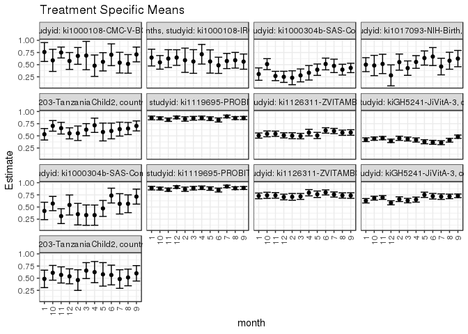

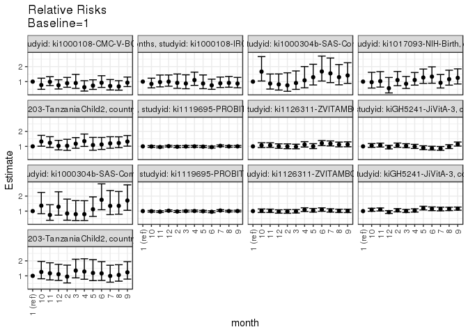

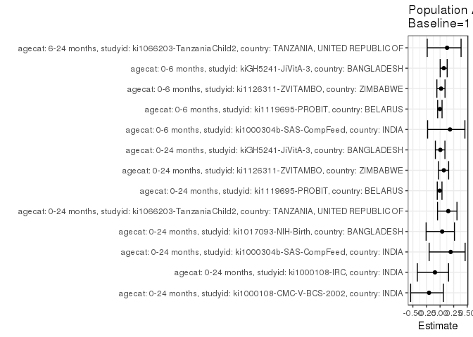

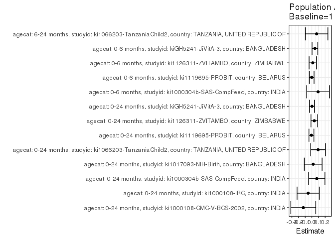

## Results Table

### Parameter: TSM

| agecat | studyid | country | intervention_level | baseline_level | estimate | ci_lower | ci_upper |
| --- | --- | --- | --- | --- | --- | --- | --- |
| 0-24 months | ki1000108-CMC-V-BCS-2002 | INDIA | 1 | NA | 0.7600000 | 0.5656718 | 0.9543282 |
| 0-24 months | ki1000108-CMC-V-BCS-2002 | INDIA | 2 | NA | 0.6800000 | 0.5077047 | 0.8522953 |
| 0-24 months | ki1000108-CMC-V-BCS-2002 | INDIA | 3 | NA | 0.6875000 | 0.3966545 | 0.9783455 |
| 0-24 months | ki1000108-CMC-V-BCS-2002 | INDIA | 4 | NA | 0.4782609 | 0.2582143 | 0.6983074 |
| 0-24 months | ki1000108-CMC-V-BCS-2002 | INDIA | 5 | NA | 0.5588235 | 0.3712718 | 0.7463752 |
| 0-24 months | ki1000108-CMC-V-BCS-2002 | INDIA | 6 | NA | 0.7037037 | 0.4793229 | 0.9280846 |
| 0-24 months | ki1000108-CMC-V-BCS-2002 | INDIA | 7 | NA | 0.5416667 | 0.3290423 | 0.7542910 |
| 0-24 months | ki1000108-CMC-V-BCS-2002 | INDIA | 8 | NA | 0.5161290 | 0.3249217 | 0.7073364 |
| 0-24 months | ki1000108-CMC-V-BCS-2002 | INDIA | 9 | NA | 0.7096774 | 0.5580315 | 0.8613233 |
| 0-24 months | ki1000108-CMC-V-BCS-2002 | INDIA | 10 | NA | 0.5882353 | 0.3614266 | 0.8150440 |
| 0-24 months | ki1000108-CMC-V-BCS-2002 | INDIA | 11 | NA | 0.7500000 | 0.6379030 | 0.8620970 |
| 0-24 months | ki1000108-CMC-V-BCS-2002 | INDIA | 12 | NA | 0.5757576 | 0.4020693 | 0.7494459 |
| 0-24 months | ki1000108-IRC | INDIA | 1 | NA | 0.6451613 | 0.4725102 | 0.8178124 |
| 0-24 months | ki1000108-IRC | INDIA | 2 | NA | 0.5909091 | 0.3417111 | 0.8401070 |
| 0-24 months | ki1000108-IRC | INDIA | 3 | NA | 0.5652174 | 0.3222657 | 0.8081691 |
| 0-24 months | ki1000108-IRC | INDIA | 4 | NA | 0.7142857 | 0.5128519 | 0.9157195 |
| 0-24 months | ki1000108-IRC | INDIA | 5 | NA | 0.5652174 | 0.3263159 | 0.8041189 |
| 0-24 months | ki1000108-IRC | INDIA | 6 | NA | 0.4864865 | 0.3200836 | 0.6528893 |
| 0-24 months | ki1000108-IRC | INDIA | 7 | NA | 0.5750000 | 0.4192159 | 0.7307841 |
| 0-24 months | ki1000108-IRC | INDIA | 8 | NA | 0.5909091 | 0.4299225 | 0.7518956 |
| 0-24 months | ki1000108-IRC | INDIA | 9 | NA | 0.5625000 | 0.4064115 | 0.7185885 |
| 0-24 months | ki1000108-IRC | INDIA | 10 | NA | 0.5476190 | 0.4075303 | 0.6877078 |
| 0-24 months | ki1000108-IRC | INDIA | 11 | NA | 0.6250000 | 0.4423429 | 0.8076571 |
| 0-24 months | ki1000108-IRC | INDIA | 12 | NA | 0.6458333 | 0.4853215 | 0.8063452 |
| 0-24 months | ki1000304b-SAS-CompFeed | INDIA | 1 | NA | 0.3064516 | 0.1791303 | 0.4337729 |
| 0-24 months | ki1000304b-SAS-CompFeed | INDIA | 2 | NA | 0.2307692 | 0.0878681 | 0.3736704 |
| 0-24 months | ki1000304b-SAS-CompFeed | INDIA | 3 | NA | 0.2790698 | 0.1465175 | 0.4116220 |
| 0-24 months | ki1000304b-SAS-CompFeed | INDIA | 4 | NA | 0.3333333 | 0.1840436 | 0.4826231 |
| 0-24 months | ki1000304b-SAS-CompFeed | INDIA | 5 | NA | 0.3968254 | 0.2795968 | 0.5140540 |
| 0-24 months | ki1000304b-SAS-CompFeed | INDIA | 6 | NA | 0.5142857 | 0.3934607 | 0.6351107 |

[output cut: 126 more lines]

### Parameter: E(Y)

| agecat | studyid | country | intervention_level | baseline_level | estimate | ci_lower | ci_upper |
| --- | --- | --- | --- | --- | --- | --- | --- |
| 0-24 months | ki1000108-CMC-V-BCS-2002 | INDIA | NA | NA | 0.6319018 | 0.5759256 | 0.6878781 |
| 0-24 months | ki1000108-IRC | INDIA | NA | NA | 0.5898734 | 0.5376978 | 0.6420491 |
| 0-24 months | ki1000304b-SAS-CompFeed | INDIA | NA | NA | 0.3808354 | 0.3457640 | 0.4159068 |
| 0-24 months | ki1017093-NIH-Birth | BANGLADESH | NA | NA | 0.5201900 | 0.4695846 | 0.5707955 |
| 0-24 months | ki1066203-TanzaniaChild2 | TANZANIA, UNITED REPUBLIC OF | NA | NA | 0.6269285 | 0.5892870 | 0.6645700 |
| 0-24 months | ki1119695-PROBIT | BELARUS | NA | NA | 0.8612051 | 0.8511051 | 0.8713052 |
| 0-24 months | ki1126311-ZVITAMBO | ZIMBABWE | NA | NA | 0.5434174 | 0.5269343 | 0.5599005 |
| 0-24 months | kiGH5241-JiVitA-3 | BANGLADESH | NA | NA | 0.4224775 | 0.4113592 | 0.4335959 |
| 0-6 months | ki1000304b-SAS-CompFeed | INDIA | NA | NA | 0.5131965 | 0.4596632 | 0.5667297 |
| 0-6 months | ki1119695-PROBIT | BELARUS | NA | NA | 0.8855266 | 0.8758983 | 0.8951550 |
| 0-6 months | ki1126311-ZVITAMBO | ZIMBABWE | NA | NA | 0.7430390 | 0.7259692 | 0.7601088 |
| 0-6 months | kiGH5241-JiVitA-3 | BANGLADESH | NA | NA | 0.6751794 | 0.6618445 | 0.6885143 |
| 6-24 months | ki1066203-TanzaniaChild2 | TANZANIA, UNITED REPUBLIC OF | NA | NA | 0.5576408 | 0.5054408 | 0.6098407 |

### Parameter: RR

| agecat | studyid | country | intervention_level | baseline_level | estimate | ci_lower | ci_upper |
| --- | --- | --- | --- | --- | --- | --- | --- |
| 0-24 months | ki1000108-CMC-V-BCS-2002 | INDIA | 1 | 1 | 1.0000000 | 1.0000000 | 1.0000000 |
| 0-24 months | ki1000108-CMC-V-BCS-2002 | INDIA | 2 | 1 | 0.8947368 | 0.6242845 | 1.2823545 |
| 0-24 months | ki1000108-CMC-V-BCS-2002 | INDIA | 3 | 1 | 0.9046053 | 0.5518016 | 1.4829799 |
| 0-24 months | ki1000108-CMC-V-BCS-2002 | INDIA | 4 | 1 | 0.6292906 | 0.3717822 | 1.0651578 |
| 0-24 months | ki1000108-CMC-V-BCS-2002 | INDIA | 5 | 1 | 0.7352941 | 0.4822107 | 1.1212058 |
| 0-24 months | ki1000108-CMC-V-BCS-2002 | INDIA | 6 | 1 | 0.9259259 | 0.6152395 | 1.3935041 |
| 0-24 months | ki1000108-CMC-V-BCS-2002 | INDIA | 7 | 1 | 0.7127193 | 0.4460851 | 1.1387263 |
| 0-24 months | ki1000108-CMC-V-BCS-2002 | INDIA | 8 | 1 | 0.6791171 | 0.4329945 | 1.0651407 |
| 0-24 months | ki1000108-CMC-V-BCS-2002 | INDIA | 9 | 1 | 0.9337861 | 0.6691942 | 1.3029945 |
| 0-24 months | ki1000108-CMC-V-BCS-2002 | INDIA | 10 | 1 | 0.7739938 | 0.4873228 | 1.2293011 |
| 0-24 months | ki1000108-CMC-V-BCS-2002 | INDIA | 11 | 1 | 0.9868421 | 0.7339288 | 1.3269098 |
| 0-24 months | ki1000108-CMC-V-BCS-2002 | INDIA | 12 | 1 | 0.7575758 | 0.5101177 | 1.1250758 |
| 0-24 months | ki1000108-IRC | INDIA | 1 | 1 | 1.0000000 | 1.0000000 | 1.0000000 |
| 0-24 months | ki1000108-IRC | INDIA | 2 | 1 | 0.9159091 | 0.5558321 | 1.5092497 |
| 0-24 months | ki1000108-IRC | INDIA | 3 | 1 | 0.8760870 | 0.5279892 | 1.4536818 |
| 0-24 months | ki1000108-IRC | INDIA | 4 | 1 | 1.1071429 | 0.7505893 | 1.6330705 |
| 0-24 months | ki1000108-IRC | INDIA | 5 | 1 | 0.8760870 | 0.5312591 | 1.4447346 |
| 0-24 months | ki1000108-IRC | INDIA | 6 | 1 | 0.7540541 | 0.4884282 | 1.1641374 |
| 0-24 months | ki1000108-IRC | INDIA | 7 | 1 | 0.8912500 | 0.6089788 | 1.3043582 |
| 0-24 months | ki1000108-IRC | INDIA | 8 | 1 | 0.9159091 | 0.6251691 | 1.3418601 |
| 0-24 months | ki1000108-IRC | INDIA | 9 | 1 | 0.8718750 | 0.5929608 | 1.2819835 |
| 0-24 months | ki1000108-IRC | INDIA | 10 | 1 | 0.8488095 | 0.5862266 | 1.2290088 |
| 0-24 months | ki1000108-IRC | INDIA | 11 | 1 | 0.9687500 | 0.6518089 | 1.4398032 |
| 0-24 months | ki1000108-IRC | INDIA | 12 | 1 | 1.0010417 | 0.6947586 | 1.4423490 |
| 0-24 months | ki1000304b-SAS-CompFeed | INDIA | 1 | 1 | 1.0000000 | 1.0000000 | 1.0000000 |
| 0-24 months | ki1000304b-SAS-CompFeed | INDIA | 2 | 1 | 0.7530364 | 0.3572460 | 1.5873202 |
| 0-24 months | ki1000304b-SAS-CompFeed | INDIA | 3 | 1 | 0.9106487 | 0.4845544 | 1.7114304 |
| 0-24 months | ki1000304b-SAS-CompFeed | INDIA | 4 | 1 | 1.0877193 | 0.5904410 | 2.0038129 |
| 0-24 months | ki1000304b-SAS-CompFeed | INDIA | 5 | 1 | 1.2949039 | 0.7778575 | 2.1556340 |
| 0-24 months | ki1000304b-SAS-CompFeed | INDIA | 6 | 1 | 1.6781955 | 1.0413652 | 2.7044691 |

[output cut: 126 more lines]

### Parameter: PAR

| agecat | studyid | country | intervention_level | baseline_level | estimate | ci_lower | ci_upper |
| --- | --- | --- | --- | --- | --- | --- | --- |
| 0-24 months | ki1000108-CMC-V-BCS-2002 | INDIA | 1 | NA | -0.1280982 | -0.3156692 | 0.0594729 |
| 0-24 months | ki1000108-IRC | INDIA | 1 | NA | -0.0552879 | -0.2222494 | 0.1116737 |
| 0-24 months | ki1000304b-SAS-CompFeed | INDIA | 1 | NA | 0.0743838 | -0.0480880 | 0.1968556 |
| 0-24 months | ki1017093-NIH-Birth | BANGLADESH | 1 | NA | 0.0201900 | -0.1136125 | 0.1539925 |
| 0-24 months | ki1066203-TanzaniaChild2 | TANZANIA, UNITED REPUBLIC OF | 1 | NA | 0.0944609 | -0.0164284 | 0.2053503 |
| 0-24 months | ki1119695-PROBIT | BELARUS | 1 | NA | -0.0061418 | -0.0433776 | 0.0310940 |
| 0-24 months | ki1126311-ZVITAMBO | ZIMBABWE | 1 | NA | 0.0375002 | -0.0132593 | 0.0882597 |
| 0-24 months | kiGH5241-JiVitA-3 | BANGLADESH | 1 | NA | 0.0023225 | -0.0347532 | 0.0393983 |
| 0-6 months | ki1000304b-SAS-CompFeed | INDIA | 1 | NA | 0.0938416 | -0.0768830 | 0.2645663 |
| 0-6 months | ki1119695-PROBIT | BELARUS | 1 | NA | -0.0025853 | -0.0382468 | 0.0330763 |
| 0-6 months | ki1126311-ZVITAMBO | ZIMBABWE | 1 | NA | 0.0141501 | -0.0413889 | 0.0696891 |
| 0-6 months | kiGH5241-JiVitA-3 | BANGLADESH | 1 | NA | 0.0464091 | 0.0030323 | 0.0897859 |
| 6-24 months | ki1066203-TanzaniaChild2 | TANZANIA, UNITED REPUBLIC OF | 1 | NA | 0.0719265 | -0.0977237 | 0.2415767 |

### Parameter: PAF

| agecat | studyid | country | intervention_level | baseline_level | estimate | ci_lower | ci_upper |
| --- | --- | --- | --- | --- | --- | --- | --- |
| 0-24 months | ki1000108-CMC-V-BCS-2002 | INDIA | 1 | NA | -0.2027184 | -0.5406919 | 0.0611155 |
| 0-24 months | ki1000108-IRC | INDIA | 1 | NA | -0.0937284 | -0.4174182 | 0.1560418 |
| 0-24 months | ki1000304b-SAS-CompFeed | INDIA | 1 | NA | 0.1953174 | -0.2007108 | 0.4607243 |
| 0-24 months | ki1017093-NIH-Birth | BANGLADESH | 1 | NA | 0.0388128 | -0.2562172 | 0.2645533 |
| 0-24 months | ki1066203-TanzaniaChild2 | TANZANIA, UNITED REPUBLIC OF | 1 | NA | 0.1506726 | -0.0465071 | 0.3107003 |
| 0-24 months | ki1119695-PROBIT | BELARUS | 1 | NA | -0.0071316 | -0.0513110 | 0.0351912 |
| 0-24 months | ki1126311-ZVITAMBO | ZIMBABWE | 1 | NA | 0.0690081 | -0.0292634 | 0.1578969 |
| 0-24 months | kiGH5241-JiVitA-3 | BANGLADESH | 1 | NA | 0.0054974 | -0.0862510 | 0.0894963 |
| 0-6 months | ki1000304b-SAS-CompFeed | INDIA | 1 | NA | 0.1828571 | -0.2287268 | 0.4565737 |
| 0-6 months | ki1119695-PROBIT | BELARUS | 1 | NA | -0.0029195 | -0.0440106 | 0.0365544 |
| 0-6 months | ki1126311-ZVITAMBO | ZIMBABWE | 1 | NA | 0.0190435 | -0.0586315 | 0.0910193 |
| 0-6 months | kiGH5241-JiVitA-3 | BANGLADESH | 1 | NA | 0.0687360 | 0.0021786 | 0.1308538 |
| 6-24 months | ki1066203-TanzaniaChild2 | TANZANIA, UNITED REPUBLIC OF | 1 | NA | 0.1289835 | -0.2360974 | 0.3862379 |